# Overview of DS002 Project 2

December 9, 2024

Ameya Teli

## Project 2: Shakespeare Textual Analysis

- This project is a textual analysis of *Romeo and Juliet*
- It is split into a few stages, 3 of which are:
  1. How much is death mentioned?
  2. Punctuation
  3. Act III Analysis
- Goal: Explore how *Romeo and Juliet* employs the theme of death and uses punctuation to understand the narrative flow

#### Source

This data was curated by [Nicola Rennie](https://github.com/nrennie) from The Complete Works of William Shakespeare (https://shakespeare.mit.edu), the Web’s first edition of the Complete Works of William Shakespeare.

## First, The Data

```
# A tibble: 6 × 5
  act   scene    character dialogue                                  line_number
  <chr> <chr>    <chr>     <chr>                                           <dbl>
1 Act I Prologue Chorus    Two households, both alike in dignity,              1
2 Act I Prologue Chorus    In fair Verona, where we lay our scene,             2
3 Act I Prologue Chorus    From ancient grudge break to new mutiny,            3
4 Act I Prologue Chorus    Where civil blood makes civil hands uncl…           4
5 Act I Prologue Chorus    From forth the fatal loins of these two …           5
6 Act I Prologue Chorus    A pair of star-cross'd lovers take their…           6
```

# How much is death mentioned?

## Which character?

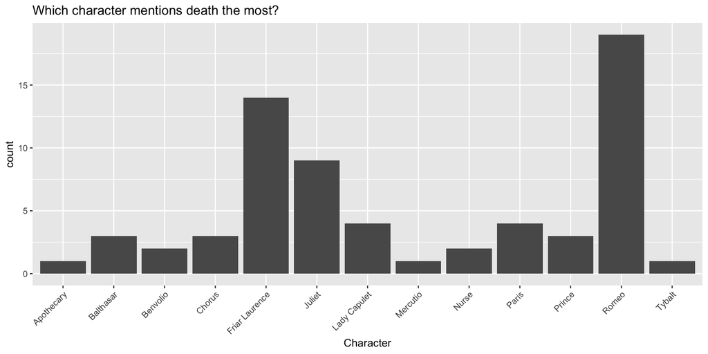

## Which character?

- Romeo and Friar Lawrence mention death the most
- Romeo being one of the characters who eventually dies & Friar Lawrence who gives Juliet the sleeping potion

## Mentions in Acts

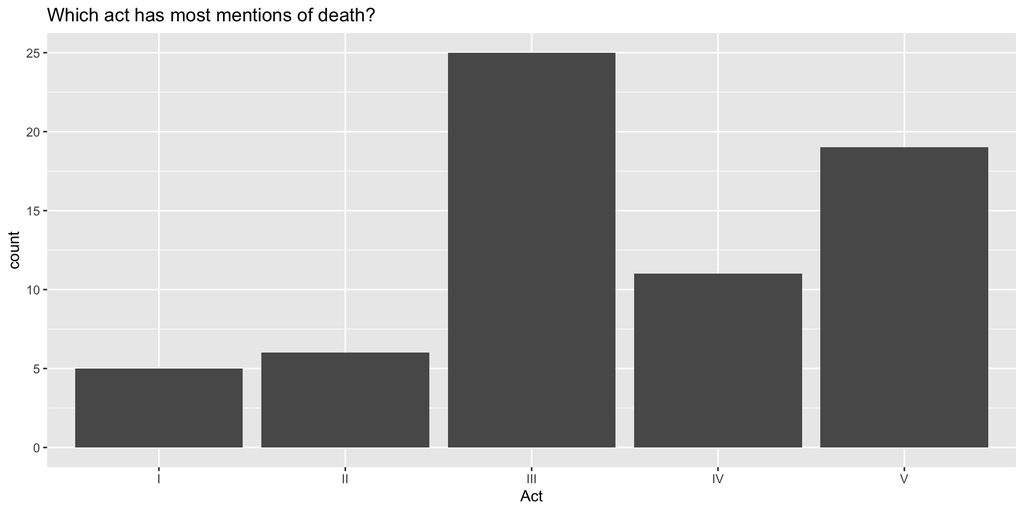

## Mentions in Acts

- Most mentions of death in Act III and Act V
- A few notable deaths occur here
- Many characters announce that they are going to die
  - “Thus with a kiss I die” -Romeo
- Other’s talk about their deaths

# Punctuation

- Not constant in every edition of *Romeo and Juliet*

## Punctuation in Act III

- In the following plot I looked at places in the dialogue with something I called “strong punctuation” which was either “!” or “?” in lines that already had the word death

## Bar Chart

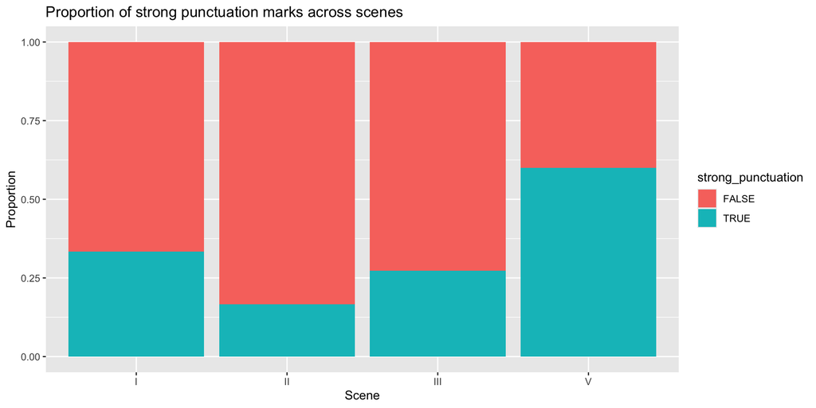

## Bar Chart

- Greater proportion of strong punctuation in Scene 5 than the rest due to high emotional intensity
- Stronger emotions related to the phrases that include a strong punctuation mark
- Important events may occur in places with stronger emotions

# Act III

## Word/Character After Death in Act III

- Because Act III has the most mentions of death I wanted to look through the act: looking at the word/character after death
- In this act two notable characters die: Tybalt and Mercutio
- Looking at the words/characters around the word “death” can tell us a lot about a moment

## Word/Character

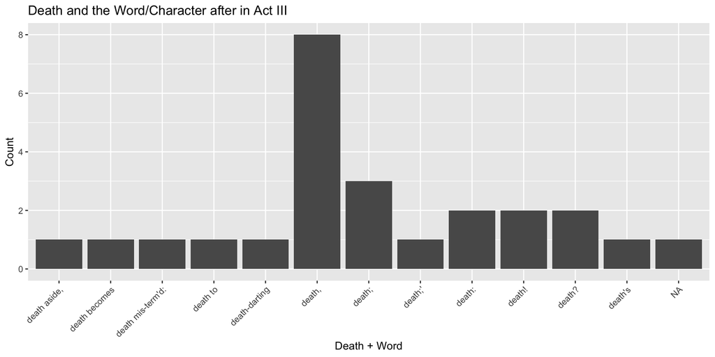

## Word/Character

- The most common thing following death is a comma, indicating that death ends a thought of most of the dialogue in Act III
- In comparison to a period which ends a sentence
- In Shakespeare’s writing, lines often end with commas or periods
- Also this is interesting for analyzing Shakespeare’s style

## Conclusion

- Death is a very important theme in *Romeo and Juliet*
- The two most death heavy scenes have the most mentions of the word “death”
- Punctation is useful to understand the emotions of the scenes that death occurs in (more strong punctuation in scene V and in act III death is most commonly followed by “,”)
- This shows that Shakespeare uses his themes very deliberatly explicitly stating “death” many times and punctuation to heighten drama